# DATA 605: Computational Mathematics Homework 1

Gabriel Campos

Last edited September 24, 2024

# Instructions

**Submit: In this course, I accept only knitted .pdfs that contain code, figures, and commentary in a professional format.**

## Libraries

```r
library("gganimate")
library("ggplot2")
library("gridExtra")
library("imager")
library("jpeg")
library("Matrix")
library("png")
library("pracma")
library("reshape2")
```

## 1. Geometric Transformation of Shapes Using Matrix Multiplication

**Context:** In computer graphics and data visualization, geometric transformations are fundamental. These transformations, such as translation, scaling, rotation, and reflection, can be applied to shapes to manipulate their appearance.

**Task:** Create a simple shape (like a square or triangle) using point plots in R. Implement R code to apply different transformations (scaling, rotation, reflection) to the shape by left multiplying a transformation matrix by each of the point vectors. Demonstrate these transformations through animated plots.

### i. Create a Shape:

**Define a simple shape (e.g., a square) using a set of point coordinates.**

```r
# construct square
square <- matrix(c(0, 0,
                   1, 0,
                   1, 1,
                   0, 1,
                   0, 0),
                 ncol = 2, byrow = TRUE)
# Make into a data frame for further use
square_df <- data.frame(x = square[,1], y = square[,2])
```

### ii. Apply Transformations:

- **Scaling:** Enlarge or shrink the shape.

```r
# Select factor to scale by
scale_factor<- 4
# copy the original square data frame
square_scaled_df <- square_df
# scale the x value
square_scaled_df$x <- square_df$x*scale_factor
# scale the y value
square_scaled_df$y <- square_df$y*scale_factor
```

- **Rotation:** Rotate the shape by a given angle.

```r
# in order to rotate by multiplying x and y by cosine and sine of the rotation
# angle

# obtain rotation angle (45 degree)
theta <- pi/4
# copy the original square data frame
square_rotate_df <- square_scaled_df
# rotate x
square_rotate_df$x <- square_scaled_df$x * cos(theta) - square_scaled_df$y * sin(theta)
# rotate y
square_rotate_df$y <- square_scaled_df$x * sin(theta) + square_scaled_df$y * cos(theta)
```

- **Reflection:** Reflect the shape across an axis.

```r
# reflect by flipping coordinates, in this case x
square_reflected_df <- square_df
square_reflected_df$x <- -square_df$x
```

**Animate Transformations:** Use a loop to incrementally change the transformation matrix and visualize the effect on the shape over time.

```r
# Make the square
ani_square <- matrix(c(0, 0,
                   1, 0,
                   1, 1,
                   0, 1,
                   0, 0),
                 ncol = 2, byrow = TRUE)

# Make square a data frame
ani_square_df <- data.frame(x = ani_square[,1], y = ani_square[,2])

# Make a sequence of scale factors and angles
ani_scale_factors <- seq(1, 2, length.out = 50)  # Scaling from 1 to 2
ani_angles <- seq(0, pi/2, length.out = 50)  # Rotate from 0 to 90 degrees

# Empty data frame for storing transformation
ani_transformed_frames <- data.frame()

# For Loop to increment through
for (i in 1:length(ani_scale_factors)) {
  # Scale and rotating variables
  ani_scale_factor <- ani_scale_factors[i]
  ani_angle <- ani_angles[i]

  # animated scale frames
  ani_scaling_matrix <- matrix(c(ani_scale_factor, 0,
                             0, ani_scale_factor),
                           nrow = 2)

  # animated rotation
  ani_rotation_matrix <- matrix(c(cos(ani_angle), -sin(ani_angle),
                              sin(ani_angle), cos(ani_angle)),
                            nrow = 2)

  # Use %*% for combining
  ani_transformation_matrix <- ani_scaling_matrix %*% ani_rotation_matrix

  # Add the transformation to square
  ani_transformed_square <- as.matrix(ani_square_df) %*% t(ani_transformation_matrix)

  # Add dataframe to step
  ani_transformed_df <- data.frame(x = ani_transformed_square[,1], y = ani_transformed_square[,2])
  ani_transformed_df$step <- i  # Step number for animation
  ani_transformed_frames <- rbind(ani_transformed_frames, ani_transformed_df)
}
```

### iii. Plot:

**Display the original shape and its transformations in your compiled pdf. Demonstrate the effect of the transformations with fixed images.**

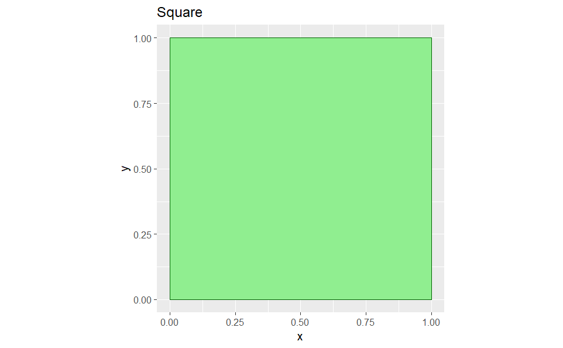

```r
ggplot(square_df, aes(x = x, y = y)) +
  geom_polygon(fill = "lightgreen", color = "darkgreen") +
  coord_fixed() + ggtitle("Square")
```

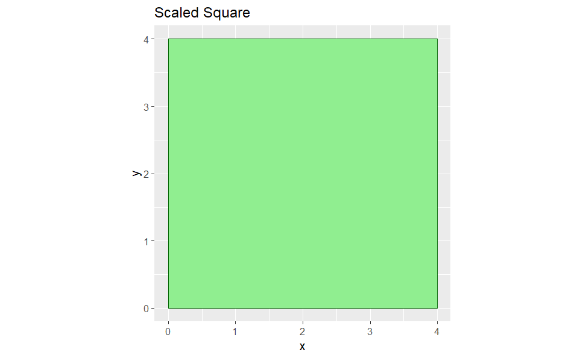

```r
ggplot(square_scaled_df, aes(x = x, y = y)) +
  geom_polygon(fill = "lightgreen", color = "darkgreen") +
  coord_fixed() + ggtitle("Scaled Square")
```

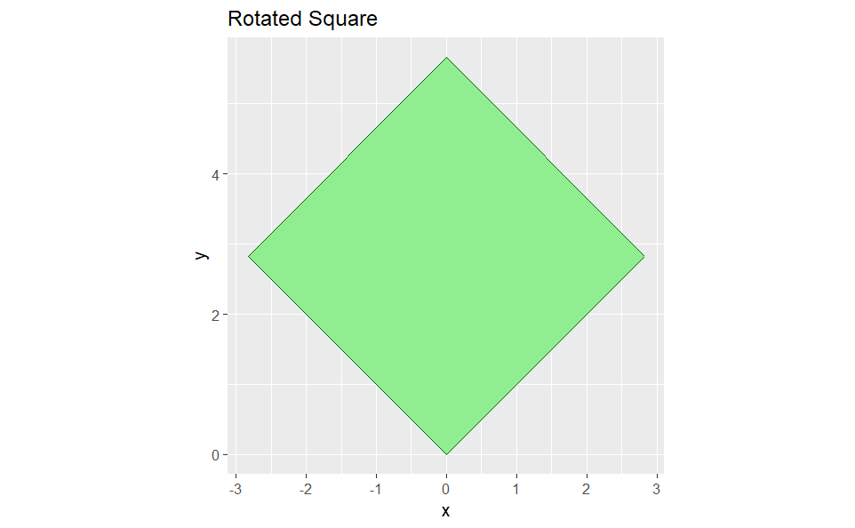

```r
ggplot(square_rotate_df, aes(x = x, y = y)) +
  geom_polygon(fill = "lightgreen", color = "darkgreen") +
  coord_fixed() + ggtitle("Rotated Square")
```

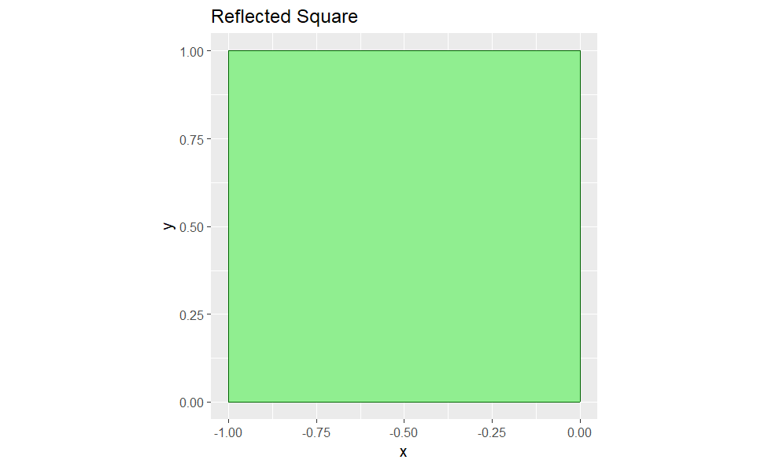

```r
ggplot(square_reflected_df, aes(x = x, y = y)) +
  geom_polygon(fill = "lightgreen", color = "darkgreen") +
  coord_fixed() + ggtitle("Reflected Square")
```

### iv. Animated Plot:

```r
animate(ggplot(ani_transformed_frames, aes(x = x, y = y, group = step)) +
  geom_polygon(fill = NA, color = "darkgreen") +
  coord_fixed() +
  transition_states(step, transition_length = 2, state_length = 1) +
  labs(title = 'Step {closest_state}') +
  ease_aes('linear'))
```

[output not shown]

[output not shown]

[output cut: 90 more lines]

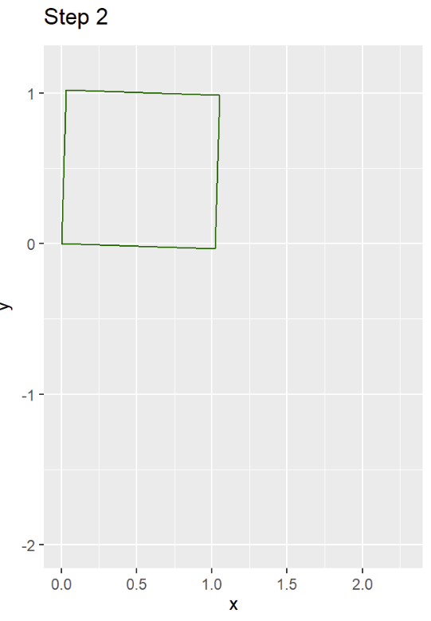

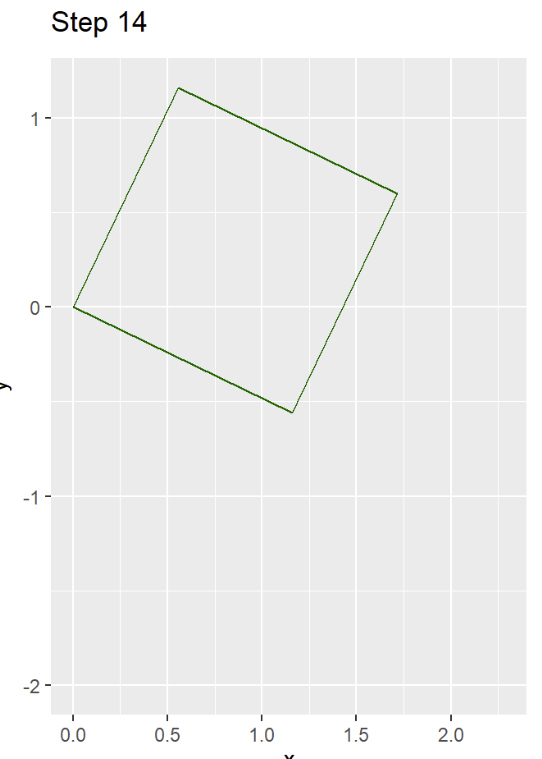

[gganimate package - RDocumentation](https://www.rdocumentation.org/packages/gganimate/versions/1.0.9) [A Grammar of Animated Graphics](https://gganimate.com/)

```r
rm(list = ls(pattern = "^(ani|i|square)"))
```

## 2. Matrix Properties and Decomposition

### i. Proofs

#### a.

- Prove that $AB\neq BA$

$$A = \begin{pmatrix}
0 & 1 \\
0 & 0 \\
\end{pmatrix} \ \
B = \begin{pmatrix}
1 & 0 \\
0 & 0 \\
\end{pmatrix}$$

$$AB = \begin{pmatrix}
0 & 1 \\
0 & 0 \\
\end{pmatrix}
\begin{pmatrix}
1 & 0 \\
0 & 0 \\
\end{pmatrix}
=
\begin{pmatrix}
0 & 0 \\
0 & 0 \\
\end{pmatrix}$$

$\therefore AB\neq BA$

#### b.

- Prove that $A^t A$ is always symmetric.

**Definition: SYM Symmetric Matrix** (Beezer : A First Course in Linear Algebra: pg. 186) The matrix A is symmetric if $A = A^t$ $\therefore A^t A = (A^t A)^t$

**Theorem TT Transpose of a Transpose** (Beezer : A First Course in Linear Algebra: pg. 168) $(A^t)^t=A$ $\therefore (A^t)^t A^t=A A^t$

Which essentially shows that $A^tA$ is equal to its own transpose.

#### c.

- Prove that the determinant of $A^T A$ is non-negative
- Multiplying the Matrix $A^t A$ results in a square matrix $(nm)(nm)=(nn) $
- Above proof shows its always symmetric.
- Symmetric Matrices have real eigen values.
- The determinant of a matrix is the product of its eigenvalues.
- So for any vector $x \in R^n$ if we consider a non zero vector x than $x^t(A^t A)x= (Ax)^t(Ax)=(Ax)(Ax)=||Ax^2||$
- $||Ax^2||$ represents the square of Euclidean norm (length) of vector $Ax$, which is always non-negative.
- With $A^tA$ positive semi-definite, its implied so are the eigen values since $\lambda \ of A^t A$ has to satisfy $x^t(A^t A)x = \lambda x^r x$
- Given
  - $x^t(A^t A)x = ||A^t|| \geq 0$
  - $x^t x$ (norm of x square) is $\lambda$
  - scales $x^tx$

$\therefore$ the equation must be non-negative as well.

### i. Singular Value Decomposition (SVD) and Image Compression

**Context:** Every time you upload a photo to social media, algorithms often compress your image to reduce file size without significantly degrading quality. One of the key techniques used in this process is Singular Value Decomposition (SVD), which is another form of matrix factorization.

**Task:** Write an R function that performs Singular Value Decomposition (SVD) on a grayscale image (which can be represented as a matrix). Use this decomposition to compress the image by keeping only the top k singular values and their corresponding vectors. Demonstrate the effect of different values of k on the compressed image’s quality. You can choose any open-access grayscale image that is appropriate for a professional program.

**Instructions:**

- **Read an Image:** Convert a grayscale image into a matrix.

```r
img <- load.image("GrayScaleIMG.jpg")
gray <- grayscale(img)
gray_matrix <- as.matrix(gray)

# Print the dimensions to confirm it's a matrix
print(dim(gray_matrix))
```

```
[1] 3000 1688
```

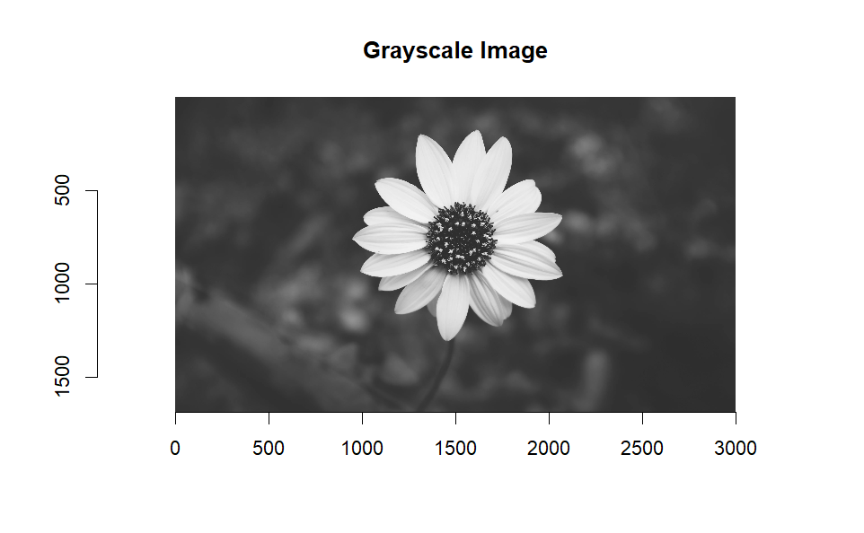

```r
plot(gray, main = "Grayscale Image")
```

- **Perform SVD:** Factorize the image matrix $A$ into $U \sum V^T$ using R’s built-in svd() function.

```r
gray_svd <- svd(gray_matrix)
gray_U<- gray_svd$u
gray_Sigma<- gray_svd$d
gray_Vt<- t(gray_svd$v)
```

- **Compress the Image:** Reconstruct the image using only the top k singular values and vectors.

```r
gray_reconstruct <- function(U,Sigma,Vt,k){
  U_k <- U[,1:k]
  Sigma_k <- diag(Sigma[1:k])
  Vt_k <- Vt[,1:k]

  img_reconstructed <- U_k %*% Sigma_k %*% t(Vt_k)

  return(img_reconstructed)
}
```

```r
# gray_reconstruct(gray_U, gray_Sigma, gray_Vt, k)
```

- **Visualize the Result:** Plot the original image alongside the compressed versions for various values of k (e.g., k = 5, 20, 50).

[figure not shown]

```r
k_values <- c(5, 20, 50)  # Values of k for compression

# Set up plotting area
par(mfrow = c(1, length(k_values) + 1)) # Arrange plots

# Visualize the original image
image(gray_matrix, col=gray.colors(256),  main = "Original Image", axes = FALSE)

# Visualize reconstructed images for different k values
for (k in k_values) {
  img_reconstructed <- gray_reconstruct(gray_U, gray_Sigma, gray_Vt, k)
    # Ensure the image matrix is properly scaled and in the correct range
  img_reconstructed <- pmax(pmin(img_reconstructed, 1), 0)  # Clip values to [0, 1] range

  # Plot the reconstructed image
  image(img_reconstructed, col=gray.colors(256), main = paste("Reconstructed k =", k), axes = FALSE)
}
```

```r
rm(list = ls())
```